# ACE

# Adverse Childhood Experience

# Exploring what the data capture methodology is returning

This quarto looks at how the codelist have transferred and being extended and which records are being returned.

The purpose is to understand whether there are any biases in the approch and whether there are any deficits.

## Read in the RDS tables

The Data prep query produces a set of RDS files that form the bases.

```r
# Load exposures

susData <- readRDS('susSrc.rds')
IAPTData <- readRDS('IAPTSrc.rds')
MHSDSData <- readRDS('MHSDSSrc.rds')
MHSDSPersonalFullData <- readRDS('MHSDSDataPersonalFullSrc.rds')
# MHSDSDataLegal <- readRDS('MHSDSDataLegalSrc.rds')
# MHSDSDataLAC <- readRDS('MHSDSDataLACSrc.rds')
# MHSDSDataEduc <- readRDS('MHSDSDataEducSrc.rds')
# MHSDSDataLDA <- readRDS('MHSDSDataLDASrc.rds')
susAPCData <- readRDS('susAPCSrc.rds')
susOPCS4Data <- readRDS('susOPCS4Src.rds')
susOPData <- readRDS('susOPSrc.rds')
AlcoholData <- readRDS('AlcoholSrc.rds')
Nine99Data <- readRDS('Nine99Src.rds')
EDData <- readRDS('EDSrc.rds')
One11Data <- readRDS('One11Src.rds')
One11WMASData <- readRDS('One11WMASSrc.rds')
RxData <- readRDS('RxSrc.rds')
MPIData <- readRDS('MPISrc.rds')
DeathsData <- readRDS('DeathSrc.rds')
csdsData <- readRDS('csdsSrc.rds')


df <- read.csv('icd102019syst_groups.csv')

ICDgroups <- df %>%
  rename(From = 1)
```

```r
# Get population table

MPIDataLatest <- MPIData %>%
  slice_max(modified_date) %>%
  filter(is.na(Death_Month),der_SICB_Code_Of_Residence == '15E' ) %>%
  select(PatientId, UPRN, Gender, Death_Month, der_Age,
         der_SICB_Code_Of_Residence, der_SICB_Code_Of_Registration,
         LSOA_2021, total_household_population, living_with_under_18_flag,
         OS_ClassificationCode, OS_ClassificationDescription,OS_BuildStatus,
         OS_Private_Outdoor_Space_Flag,
         CACI_Household_Acorn_Type, CACI_Household_Acorn_Type_Description,
         EPC_Property, EPC_BuiltForm, EPC_Tenure,
         modified_date
  )

  households <- MPIDataLatest %>%
  arrange(UPRN) %>%              # ensure ordering
  group_by(UPRN) %>%             # regroup after join
  mutate(row_id = row_number()) %>% # row number per UPRN
  filter(row_id == 1) %>%
    ungroup()

  rm(MPIData)
```

```r
allACEcriteria <- susData %>%
  filter(!is.na(PatientId)) %>%
  select(
        event,
        PatientId,
        coding_term,
        ACE_indicator_code,
        indicator_specific,
        indicator_1,
        indicator_2,
        domain,
        severity,
        system,
        cut_off) %>%
  union(susAPCData   %>%
          select(
            event,
         PatientId,
        coding_term,
        ACE_indicator_code,
        indicator_specific,
        indicator_1,
        indicator_2,
        domain,
        severity,
        system,
        cut_off)
            %>% filter(!is.na(PatientId)))%>%
  union(susOPCS4Data
            %>% select(
              event,
         PatientId,
        coding_term,
        ACE_indicator_code,
        indicator_specific,
        indicator_1,
        indicator_2,
        domain,
        severity,
        system,
        cut_off)
            %>% filter(!is.na(PatientId))) %>%
  union(susOPData
            %>% select(
              event,
         PatientId,
        coding_term,
        ACE_indicator_code,
        indicator_specific,
        indicator_1,
        indicator_2,
        domain,
        severity,
        system,
        cut_off)
            %>% filter(!is.na(PatientId)))  %>%
  union(MHSDSData
            %>% select(
              event,
         PatientId,
        coding_term,
        ACE_indicator_code,
        indicator_specific,
        indicator_1,
        indicator_2,
        domain,
        severity,
        system,
        cut_off)
            %>% filter(!is.na(PatientId))) %>%
  union(MHSDSPersonalFullData
        %>% select(
          event,
          PatientId,
          coding_term,
          ACE_indicator_code,
          indicator_specific,
          indicator_1,
          indicator_2,
          domain,
          severity,
          system,
          cut_off)
        %>% filter(!is.na(PatientId))) %>%
  union(One11Data
            %>% select(
              event,
         PatientId,
        coding_term,
        ACE_indicator_code,
        indicator_specific,
        indicator_1,
        indicator_2,
        domain,
        severity,
        system,
        cut_off)
            %>% filter(!is.na(PatientId))) %>%
  union(One11WMASData
            %>% select(
              event,
         PatientId,
        coding_term,
        ACE_indicator_code,
        indicator_specific,
        indicator_1,
        indicator_2,
        domain,
        severity,
        system,
        cut_off)
            %>% filter(!is.na(PatientId))) %>%
   union(IAPTData
             %>% select(
               event,
         PatientId,
        coding_term,
        ACE_indicator_code,
        indicator_specific,
        indicator_1,
        indicator_2,
        domain,
        severity,
        system,
        cut_off)
             %>% filter(!is.na(PatientId))) %>%
  union(AlcoholData
            %>% select(
              event,
         PatientId,
        coding_term,
        ACE_indicator_code,
        indicator_specific,
        indicator_1,
        indicator_2,
        domain,
        severity,
        system,
        cut_off)
            %>% filter(!is.na(PatientId))) %>%
  union(Nine99Data
            %>% select(
              event,
         PatientId,
        coding_term,
        ACE_indicator_code,
        indicator_specific,
        indicator_1,
        indicator_2,
        domain,
        severity,
        system,
        cut_off)
            %>% filter(!is.na(PatientId)))  %>%
  union(EDData
            %>% select(
              event,
         PatientId,
        coding_term,
        ACE_indicator_code,
        indicator_specific,
        indicator_1,
        indicator_2,
        domain,
        severity,
        system,
        cut_off)
            %>% filter(!is.na(PatientId)))   %>%
  union(RxData
            %>% select(
              event,
         PatientId,
        coding_term,
        ACE_indicator_code,
        indicator_specific,
        indicator_1,
        indicator_2,
        domain,
        severity,
        system,
        cut_off)
            %>% filter(!is.na(PatientId) ))

#rm(susAPCData, susData, susOPCS4Data, susOPData, RxData, Nine99Data, One11Data, One11WMASData, AlcoholData, EDData, MHSDSData,MHSDSDataEduc, MHSDSDataLAC, MHSDSDataLDA,MHSDSDataLegal,  IAPTData, DeathsData)
```

```r
HHSLivinginSingleAdultHHS <- MPIDataLatest %>%
  filter(!is.na(UPRN), living_with_under_18_flag == 'Y') %>% #hhs with children
  mutate(adult = if_else(der_Age >18,1,0)) %>% # how many adults
  summarise(adults = sum(adult), .by  = UPRN) %>%
  filter(adults == 1)  %>%
  mutate(domain = 'PS')
```

```r
## Exposures matched to people
#Subset the data for BSol and over under 18
#change to inner join

ACEBsol <- allACEcriteria %>%
              inner_join(MPIDataLatest) %>%
  filter( der_SICB_Code_Of_Residence == '15E', is.na(Death_Month),
          (der_Age <19 | living_with_under_18_flag == 'Y')) %>%  # have to be a child or adult living with under 18
   mutate( coding_term = str_to_title(coding_term),
           indicator_specific = str_to_title(indicator_specific),
           indicator_1 = str_to_title(indicator_1),
           indicator_2 = str_to_title(indicator_2))

peopleMeetingCriteria <- ACEBsol %>%
              summarise( ACEFlags = n(), .by = c(PatientId, der_Age, indicator_specific,coding_term) )

MPIUnder18BSol <- MPIDataLatest %>%
  filter(der_Age < 19)

Under18BSolCount <- nrow(peopleMeetingCriteria  %>%
  filter(der_Age < 19) %>%
    summarise(n = n(), .by = PatientId))

MPIUnder18BSolCount <- nrow(MPIUnder18BSol  %>%
                              summarise(n = n(), .by = PatientId))

MPIOver18BSol <- MPIDataLatest %>%
  filter(der_Age >= 19)

Over18BSolCount <- nrow(peopleMeetingCriteria  %>%
  filter(der_Age >= 19) %>%
    summarise(n = n(), .by = PatientId))

MPIOver18BSolCount <- nrow(MPIOver18BSol  %>%
                             summarise(n = n(), .by = PatientId))
```

## The 10 question areas

- Emotional abuse
- Physical abuse
- Sexual abuse
- Emotional neglect
- Physical neglect
- Witnessing intimate partner violence
- Household substance abuse
- Household mental illness
- Parental divorce or separation
- Household incarceration - no data on whether anyone in household had been incarcerated

## Domains

Using the ACEinEHR code list, and local algorithm we get 6 domains

**Adverse family environments (AFE)**

This domain includes indicators of adverse family environments (AFE), aligning with the original ACE domain “household challenges”. We define an AFE as any clinically intervenable psychosocial risk factor or experience recorded in the child or the parent

**Child maltreatment (CM)**

This domain includes indicators of child maltreatment (CM). CM refers to any act of commission or omission by a parent or other caregiver that results in harm, potential for harm, or threat of harm to a child. This domain includes the *High-risk presentations of child maltreatment (HRP-CM)* that includes indicators of high-risk presentations of child maltreatment (HRP-CM), consistent with NICE Clinical guidelines (CG89 and NG76) on alerting features that should raise clinical suspicions for CM.

**Intimate partner violence (IPV)**

This domain includes indicators of intimate partner violence (IPV). The WHO defines IPV as any behaviour within an intimate relationship that causes physical, psychological or sexual harm to those in the relationship. IPV indicators are restricted to parents aged ≥16.

**Parental mental health problems (MHP)**

This domain includes indicators of mental health problems (MHP) recorded in the parent concurrent with classifications laid out within the current ICD-10, excluding indicators of substance misuse.

**Parental Substance misuse (SM)**

This domain includes indicators of substance misuse (SM) recorded in the parent concurrent with classifications laid out within the current ICD-10.

**Parental Separation (PS)**

Children living in a single parent household, this is captured in a different process.

## Code lists

Conditions are not unique to 1 domain. The venn diagram below shows where the conditions occur in more than one domain.

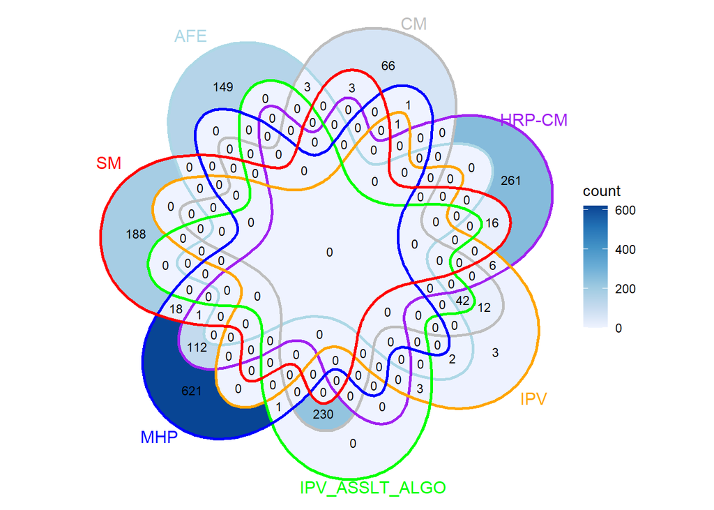

# People with a ACE flag condition

## By domain

```r
# set up exposure table from long to wide

exposureTable <- ACEBsol %>%
  mutate(count = 1,
         domain = if_else(domain == 'IPV_ASSLT_ALGO', 'IPV',domain )) %>%
  select(-c('indicator_specific', 'indicator_1', 'indicator_2', 'ACE_indicator_code', 'coding_term', 'severity', 'cut_off', 'system')) %>%
  summarise(domainCount = n(), .by = c(PatientId, UPRN, Gender, der_Age, domain)) %>%
  pivot_wider(names_from = domain,
    values_from = c('domain','domainCount'),
   # take first occurrence
    values_fill = NA) %>%
  mutate(domainSentance = str_replace_all(paste(domain_AFE,`domain_HRP-CM`, domain_MHP,domain_SM, domain_IPV,domain_CM),'NA',''),
         domainSentance = str_trim(domainSentance),
domainSentance = str_replace_all(domainSentance,' ','_'),
domainSentance = str_replace_all(domainSentance, "_____",
                                  ":"),
domainSentance = str_replace_all(domainSentance, "____",
                                  ":"),
domainSentance = str_replace_all(domainSentance, "___",
                                  ":"),
domainSentance = str_replace_all(domainSentance, "__",
                                  ":"),
domainSentance = str_replace_all(domainSentance, "_",
                                  ":")
)
```

```r
#Split exposure into under over 18

ACEgt18 <- exposureTable %>%
  filter(der_Age > 18)

ACEHHS <- ACEgt18 %>%
  summarise(n = n(), .by = UPRN)

domain_summary <- ACEgt18 %>%
  select(UPRN, starts_with("domain_")) %>%
  pivot_longer(
    cols = starts_with("domain_"),
    names_to = "domain_col",
    values_to = "domain"
  ) %>%
  filter(!is.na(domain)) %>%
  count(UPRN, domain, name = "n") %>%
  pivot_wider(
    names_from = domain,
    values_from = n,
    values_fill = 0
  )

AdultsInHHS <- ACEgt18 %>%
  summarise(Adults = n(), .by= UPRN)  %>%
  left_join(domain_summary)
```

## Adults identified as having had an event that would lead to a child experiencing an ACE

Number of adults by domain, adults will be in more than one domain.

[interactive chart not shown]

## Adults Intimate partner violence (IPV)

**Systems**

[interactive chart not shown]

**ICD10 IP**

[interactive chart not shown]

**ICD 10 dive in**

[interactive chart not shown]

**codelist**

| code | coding_term | system | indicator_specific | indicator_1 | indicator_2 |
| --- | --- | --- | --- | --- | --- |
| S300 | Contusion of lower back and pelvis | ICD-10 | Bruising & contusions | Mother assaulted + high-risk presentations (algorithm) | Suspected IPV (susp. IPV) |
| S301 | Contusion of abdominal wall | ICD-10 | Bruising & contusions | Mother assaulted + high-risk presentations (algorithm) | Suspected IPV (susp. IPV) |
| S500 | Contusion of elbow | ICD-10 | Bruising & contusions | Mother assaulted + high-risk presentations (algorithm) | Suspected IPV (susp. IPV) |
| S501 | Contusion of other and unspecified parts of forearm | ICD-10 | Bruising & contusions | Mother assaulted + high-risk presentations (algorithm) | Suspected IPV (susp. IPV) |
| S701 | Contusion of thigh | ICD-10 | Bruising & contusions | Mother assaulted + high-risk presentations (algorithm) | Suspected IPV (susp. IPV) |
| S801 | Contusion of other and unspecified parts of lower leg | ICD-10 | Bruising & contusions | Mother assaulted + high-risk presentations (algorithm) | Suspected IPV (susp. IPV) |
| T74 | Maltreatment syndromes | ICD-10 | Parental intimate partner violence NOS | IPV, NOS (incl. physical/sexual abuse) | IPV |
| T740 | Neglect or abandonment | ICD-10 | Parental intimate partner violence NOS | IPV, NOS (incl. physical/sexual abuse) | IPV |
| T741 | Physical abuse | ICD-10 | Physical abuse, IPV | IPV, NOS (incl. physical/sexual abuse) | IPV |
| T742 | Sexual abuse | ICD-10 | Sexual abuse, IPV | Suspected IPV, physical or sexual abuse | Suspected IPV (susp. IPV) |
| T743 | Psychological abuse | ICD-10 | Parental intimate partner violence NOS | IPV, NOS (incl. physical/sexual abuse) | IPV |
| T748 | Other maltreatment syndromes | ICD-10 | Parental intimate partner violence NOS | IPV, NOS (incl. physical/sexual abuse) | IPV |
| T749 | Maltreatment syndrome, unspecified | ICD-10 | Parental intimate partner violence NOS | IPV, NOS (incl. physical/sexual abuse) | IPV |
| X910 | Assault by hanging, strangulation and suffocation | ICD-10 | Assault NOS, IPV | Mother assaulted NOS (hospital admission only) | Suspected IPV (susp. IPV) |
| X919 | Assault by hanging, strangulation and suffocation | ICD-10 | Assault NOS, IPV | Mother assaulted NOS (hospital admission only) | Suspected IPV (susp. IPV) |
| X920 | Assault by drowning and submersion | ICD-10 | Assault NOS, IPV | Mother assaulted NOS (hospital admission only) | Suspected IPV (susp. IPV) |
| X929 | Assault by drowning and submersion | ICD-10 | Assault NOS, IPV | Mother assaulted NOS (hospital admission only) | Suspected IPV (susp. IPV) |
| X930 | Assault by handgun discharge | ICD-10 | Assault NOS, IPV | Mother assaulted NOS (hospital admission only) | Suspected IPV (susp. IPV) |
| X939 | Assault by handgun discharge | ICD-10 | Assault NOS, IPV | Mother assaulted NOS (hospital admission only) | Suspected IPV (susp. IPV) |
| X940 | Assault by rifle, shotgun and larger firearm discharge | ICD-10 | Assault NOS, IPV | Mother assaulted NOS (hospital admission only) | Suspected IPV (susp. IPV) |
| X949 | Assault by rifle, shotgun and larger firearm discharge | ICD-10 | Assault NOS, IPV | Mother assaulted NOS (hospital admission only) | Suspected IPV (susp. IPV) |
| X950 | Assault by other and unspecified firearm discharge | ICD-10 | Assault NOS, IPV | Mother assaulted NOS (hospital admission only) | Suspected IPV (susp. IPV) |
| X959 | Assault by other and unspecified firearm discharge | ICD-10 | Assault NOS, IPV | Mother assaulted NOS (hospital admission only) | Suspected IPV (susp. IPV) |
| X960 | Assault by explosive material | ICD-10 | Assault NOS, IPV | Mother assaulted NOS (hospital admission only) | Suspected IPV (susp. IPV) |
| X969 | Assault by explosive material | ICD-10 | Assault NOS, IPV | Mother assaulted NOS (hospital admission only) | Suspected IPV (susp. IPV) |
| X970 | Assault by smoke, fire and flames | ICD-10 | Assault NOS, IPV | Mother assaulted NOS (hospital admission only) | Suspected IPV (susp. IPV) |
| X979 | Assault by smoke, fire and flames | ICD-10 | Assault NOS, IPV | Mother assaulted NOS (hospital admission only) | Suspected IPV (susp. IPV) |
| X99 | Assault by sharp object | ICD-10 | Assault NOS, IPV | Mother assaulted NOS (hospital admission only) | Suspected IPV (susp. IPV) |
| X990 | Assault by sharp object | ICD-10 | Assault NOS, IPV | Mother assaulted NOS (hospital admission only) | Suspected IPV (susp. IPV) |
| X991 | Assault by sharp object | ICD-10 | Assault NOS, IPV | Mother assaulted NOS (hospital admission only) | Suspected IPV (susp. IPV) |
| X992 | Assault by sharp object | ICD-10 | Assault NOS, IPV | Mother assaulted NOS (hospital admission only) | Suspected IPV (susp. IPV) |
| X993 | Assault by sharp object | ICD-10 | Assault NOS, IPV | Mother assaulted NOS (hospital admission only) | Suspected IPV (susp. IPV) |
| X994 | Assault by sharp object | ICD-10 | Assault NOS, IPV | Mother assaulted NOS (hospital admission only) | Suspected IPV (susp. IPV) |
| X995 | Assault by sharp object | ICD-10 | Assault NOS, IPV | Mother assaulted NOS (hospital admission only) | Suspected IPV (susp. IPV) |
| X996 | Assault by sharp object | ICD-10 | Assault NOS, IPV | Mother assaulted NOS (hospital admission only) | Suspected IPV (susp. IPV) |
| X997 | Assault by sharp object | ICD-10 | Assault NOS, IPV | Mother assaulted NOS (hospital admission only) | Suspected IPV (susp. IPV) |
| X998 | Assault by sharp object | ICD-10 | Assault NOS, IPV | Mother assaulted NOS (hospital admission only) | Suspected IPV (susp. IPV) |
| X999 | Assault by sharp object | ICD-10 | Assault NOS, IPV | Mother assaulted NOS (hospital admission only) | Suspected IPV (susp. IPV) |
| Y000 | Assault by blunt object | ICD-10 | Assault NOS, IPV | Mother assaulted NOS (hospital admission only) | Suspected IPV (susp. IPV) |
| Y009 | Assault by blunt object | ICD-10 | Assault NOS, IPV | Mother assaulted NOS (hospital admission only) | Suspected IPV (susp. IPV) |
| Y010 | Assault by pushing from high place | ICD-10 | Assault NOS, IPV | Mother assaulted NOS (hospital admission only) | Suspected IPV (susp. IPV) |
| Y019 | Assault by pushing from high place | ICD-10 | Assault NOS, IPV | Mother assaulted NOS (hospital admission only) | Suspected IPV (susp. IPV) |
| Y020 | Assault by pushing or placing victim before moving object | ICD-10 | Assault NOS, IPV | Mother assaulted NOS (hospital admission only) | Suspected IPV (susp. IPV) |
| Y029 | Assault by pushing or placing victim before moving object | ICD-10 | Assault NOS, IPV | Mother assaulted NOS (hospital admission only) | Suspected IPV (susp. IPV) |
| Y040 | Assault by bodily force | ICD-10 | Assault NOS, IPV | Mother assaulted NOS (hospital admission only) | Suspected IPV (susp. IPV) |
| Y049 | Assault by bodily force | ICD-10 | Assault NOS, IPV | Mother assaulted NOS (hospital admission only) | Suspected IPV (susp. IPV) |
| Y050 | Sexual assault by bodily force | ICD-10 | Sexual abuse, IPV | Suspected IPV, physical or sexual abuse | Suspected IPV (susp. IPV) |
| Y059 | Sexual assault by bodily force | ICD-10 | Sexual abuse, IPV | Suspected IPV, physical or sexual abuse | Suspected IPV (susp. IPV) |
| Y060 | By spouse or partner | ICD-10 | Parental intimate partner violence NOS | IPV, NOS (incl. physical/sexual abuse) | IPV |
| Y070 | By spouse or partner | ICD-10 | Parental intimate partner violence NOS | IPV, NOS (incl. physical/sexual abuse) | IPV |
| Y072 | By acquaintance or friend | ICD-10 | Parental intimate partner violence NOS | Suspected IPV NOS | Suspected IPV (susp. IPV) |
| Y078 | By other specified persons | ICD-10 | Parental intimate partner violence NOS | Suspected IPV NOS | Suspected IPV (susp. IPV) |
| Y079 | By unspecified person | ICD-10 | Parental intimate partner violence NOS | Suspected IPV NOS | Suspected IPV (susp. IPV) |
| Y080 | Assault by other specified means | ICD-10 | Assault NOS, IPV | Mother assaulted NOS (hospital admission only) | Suspected IPV (susp. IPV) |
| Y084 | Assault by other specified means | ICD-10 | Assault NOS, IPV | Mother assaulted NOS (hospital admission only) | Suspected IPV (susp. IPV) |
| Y088 | Assault by other specified means | ICD-10 | Assault NOS, IPV | Mother assaulted NOS (hospital admission only) | Suspected IPV (susp. IPV) |
| Y089 | Assault by other specified means | ICD-10 | Assault NOS, IPV | Mother assaulted NOS (hospital admission only) | Suspected IPV (susp. IPV) |
| Y090 | Assault by unspecified means | ICD-10 | Assault NOS, IPV | Mother assaulted NOS (hospital admission only) | Suspected IPV (susp. IPV) |
| Y094 | Assault by unspecified means | ICD-10 | Assault NOS, IPV | Mother assaulted NOS (hospital admission only) | Suspected IPV (susp. IPV) |
| Y098 | Assault by unspecified means | ICD-10 | Assault NOS, IPV | Mother assaulted NOS (hospital admission only) | Suspected IPV (susp. IPV) |
| Y099 | Assault by unspecified means | ICD-10 | Assault NOS, IPV | Mother assaulted NOS (hospital admission only) | Suspected IPV (susp. IPV) |
| Y871 | Sequelae of assault | ICD-10 | Assault NOS, IPV | Mother assaulted NOS (hospital admission only) | Suspected IPV (susp. IPV) |
| Z045 | Examination and observation following other inflicted injury | ICD-10 | Physical abuse, IPV | Suspected IPV, physical or sexual abuse | Suspected IPV (susp. IPV) |
| Z33 | Pregnant state, incidental | ICD-10 | Pregnant state, incidental | Mother assaulted + child protection recording or pregnant incident | IPV |
| Z630 | Problems in relationship with spouse or partner | ICD-10 | Parental conflict/relationship problems | Mother assaulted + high-risk presentations (algorithm) | Suspected IPV (susp. IPV) |
| Z631 | Problems in relationship with parents and in-laws | ICD-10 | Parental conflict/relationship problems | Mother assaulted + high-risk presentations (algorithm) | Suspected IPV (susp. IPV) |
| Z654 | Victim of crime and terrorism | ICD-10 | Assault NOS, IPV | Mother assaulted NOS (hospital admission only) | Suspected IPV (susp. IPV) |
| Z762 | Health supervision and care of other healthy infant and child | ICD-10 | Seen by/referral to health visitor | Mother assaulted + high-risk presentations (algorithm) | Suspected IPV (susp. IPV) |
| aear_20 | Assault | HES_OP_AE | Assault NOS, IPV | Mother assaulted NOS (hospital admission only) | Suspected IPV (susp. IPV) |

## Adults Adverse family environments (AFE)

**systems**

[interactive chart not shown]

**icd IP**

[interactive chart not shown]

**ICD10 dive in**

[interactive chart not shown]

**codelist**

| code | coding_term | system | indicator_specific | indicator_1 | indicator_2 |
| --- | --- | --- | --- | --- | --- |
| F067 | Mild cognitive disorder | ICD-10 | Learning or intellectual disability | Learning or intellectual disability | Vulnerable families |
| F70 | Mild mental retardation | ICD-10 | Learning or intellectual disability | Learning or intellectual disability | Vulnerable families |
| F700 | Mild mental retardation | ICD-10 | Learning or intellectual disability | Learning or intellectual disability | Vulnerable families |
| F701 | Mild mental retardation | ICD-10 | Learning or intellectual disability | Learning or intellectual disability | Vulnerable families |
| F708 | Mild mental retardation | ICD-10 | Learning or intellectual disability | Learning or intellectual disability | Vulnerable families |
| F709 | Mild mental retardation | ICD-10 | Learning or intellectual disability | Learning or intellectual disability | Vulnerable families |
| F71 | Moderate mental retardation | ICD-10 | Learning or intellectual disability | Learning or intellectual disability | Vulnerable families |
| F710 | Moderate mental retardation | ICD-10 | Learning or intellectual disability | Learning or intellectual disability | Vulnerable families |
| F711 | Moderate mental retardation | ICD-10 | Learning or intellectual disability | Learning or intellectual disability | Vulnerable families |
| F718 | Moderate mental retardation | ICD-10 | Learning or intellectual disability | Learning or intellectual disability | Vulnerable families |
| F719 | Moderate mental retardation | ICD-10 | Learning or intellectual disability | Learning or intellectual disability | Vulnerable families |
| F72 | Severe mental retardation | ICD-10 | Learning or intellectual disability | Learning or intellectual disability | Vulnerable families |
| F720 | Severe mental retardation | ICD-10 | Learning or intellectual disability | Learning or intellectual disability | Vulnerable families |
| F721 | Severe mental retardation | ICD-10 | Learning or intellectual disability | Learning or intellectual disability | Vulnerable families |
| F728 | Severe mental retardation | ICD-10 | Learning or intellectual disability | Learning or intellectual disability | Vulnerable families |
| F729 | Severe mental retardation | ICD-10 | Learning or intellectual disability | Learning or intellectual disability | Vulnerable families |
| F73 | Profound mental retardation | ICD-10 | Learning or intellectual disability | Learning or intellectual disability | Vulnerable families |
| F730 | Profound mental retardation | ICD-10 | Learning or intellectual disability | Learning or intellectual disability | Vulnerable families |
| F731 | Profound mental retardation | ICD-10 | Learning or intellectual disability | Learning or intellectual disability | Vulnerable families |
| F738 | Profound mental retardation | ICD-10 | Learning or intellectual disability | Learning or intellectual disability | Vulnerable families |
| F739 | Profound mental retardation | ICD-10 | Learning or intellectual disability | Learning or intellectual disability | Vulnerable families |
| F78 | Other mental retardation | ICD-10 | Learning or intellectual disability | Learning or intellectual disability | Vulnerable families |
| F780 | Other mental retardation | ICD-10 | Learning or intellectual disability | Learning or intellectual disability | Vulnerable families |
| F781 | Other mental retardation | ICD-10 | Learning or intellectual disability | Learning or intellectual disability | Vulnerable families |
| F788 | Other mental retardation | ICD-10 | Learning or intellectual disability | Learning or intellectual disability | Vulnerable families |
| F789 | Other mental retardation | ICD-10 | Learning or intellectual disability | Learning or intellectual disability | Vulnerable families |
| F79 | Unspecified mental retardation | ICD-10 | Learning or intellectual disability | Learning or intellectual disability | Vulnerable families |
| F790 | Unspecified mental retardation | ICD-10 | Learning or intellectual disability | Learning or intellectual disability | Vulnerable families |
| F791 | Unspecified mental retardation | ICD-10 | Learning or intellectual disability | Learning or intellectual disability | Vulnerable families |
| F798 | Unspecified mental retardation | ICD-10 | Learning or intellectual disability | Learning or intellectual disability | Vulnerable families |

[output cut: 125 more lines]

## Adults Parental Substance misuse (SM)

**Systems**

[interactive chart not shown]

**ICD10 IP**

[interactive chart not shown]

**ICD10 dive in**

[interactive chart not shown]

**codelist**

| code | coding_term | system | indicator_specific | indicator_1 | indicator_2 |
| --- | --- | --- | --- | --- | --- |
| 5712 | Alcoholiccirrhosisofliver | ICD-9 | Alcohol misuse | Alcohol misuse, severe (incl. self-report measures/units per week) | Alcohol misuse |
| 5713 | Alcoholicliverdamageunspecified | ICD-9 | Alcohol misuse | Alcohol misuse, severe (incl. self-report measures/units per week) | Alcohol misuse |
| E242 | Drug-induced Cushing syndrome | ICD-10 | Drug misuse | Drug misuse, severe (likely dependence levels) | Drug misuse |
| E244 | Alcohol-induced pseudo-Cushing syndrome | ICD-10 | Alcohol misuse | Alcohol misuse, severe (incl. self-report measures/units per week) | Alcohol misuse |
| E512 | Wernickeencephalopathy | ICD-10 | Alcohol misuse | Alcohol misuse, severe (incl. self-report measures/units per week) | Alcohol misuse |
| E8500 |  | ICD-9 | Drug misuse | Drug misuse, severe (likely dependence levels) | Drug misuse |
| E9350 |  | ICD-9 | Drug misuse | Drug misuse, severe (likely dependence levels) | Drug misuse |
| F10 | Mental and behavioural disorders due to use of alcohol | ICD-10 | Alcohol misuse | Alcohol misuse, severe (incl. self-report measures/units per week) | Alcohol misuse |
| F100 | Mental and behavioural disorders due to use of alcohol | ICD-10 | Alcohol misuse | Alcohol misuse, severe (incl. self-report measures/units per week) | Alcohol misuse |
| F101 | Mental and behavioural disorders due to use of alcohol | ICD-10 | Alcohol misuse | Alcohol misuse, severe (incl. self-report measures/units per week) | Alcohol misuse |
| F102 | Mental and behavioural disorders due to use of alcohol | ICD-10 | Alcohol misuse | Alcohol misuse, severe (incl. self-report measures/units per week) | Alcohol misuse |
| F103 | Mental and behavioural disorders due to use of alcohol | ICD-10 | Alcohol misuse | Alcohol misuse, severe (incl. self-report measures/units per week) | Alcohol misuse |
| F104 | Mental and behavioural disorders due to use of alcohol | ICD-10 | Alcohol misuse | Alcohol misuse, severe (incl. self-report measures/units per week) | Alcohol misuse |
| F105 | Mental and behavioural disorders due to use of alcohol | ICD-10 | Alcohol misuse | Alcohol misuse, severe (incl. self-report measures/units per week) | Alcohol misuse |
| F106 | Mental and behavioural disorders due to use of alcohol | ICD-10 | Alcohol misuse | Alcohol misuse, severe (incl. self-report measures/units per week) | Alcohol misuse |
| F107 | Mental and behavioural disorders due to use of alcohol | ICD-10 | Alcohol misuse | Alcohol misuse, severe (incl. self-report measures/units per week) | Alcohol misuse |
| F108 | Mental and behavioural disorders due to use of alcohol | ICD-10 | Alcohol misuse | Alcohol misuse, severe (incl. self-report measures/units per week) | Alcohol misuse |
| F109 | Mental and behavioural disorders due to use of alcohol | ICD-10 | Alcohol misuse | Alcohol misuse, severe (incl. self-report measures/units per week) | Alcohol misuse |
| F11 | Mental and behavioural disorders due to use of opioids | ICD-10 | Drug misuse | Drug misuse, severe (likely dependence levels) | Drug misuse |
| F110 | Mental and behavioural disorders due to use of opioids | ICD-10 | Drug misuse | Drug misuse, severe (likely dependence levels) | Drug misuse |
| F111 | Mental and behavioural disorders due to use of opioids | ICD-10 | Drug misuse | Drug misuse, severe (likely dependence levels) | Drug misuse |
| F112 | Mental and behavioural disorders due to use of opioids | ICD-10 | Drug misuse | Drug misuse, severe (likely dependence levels) | Drug misuse |
| F113 | Mental and behavioural disorders due to use of opioids | ICD-10 | Drug misuse | Drug misuse, severe (likely dependence levels) | Drug misuse |
| F114 | Mental and behavioural disorders due to use of opioids | ICD-10 | Drug misuse | Drug misuse, severe (likely dependence levels) | Drug misuse |
| F115 | Mental and behavioural disorders due to use of opioids | ICD-10 | Drug misuse | Drug misuse, severe (likely dependence levels) | Drug misuse |
| F116 | Mental and behavioural disorders due to use of opioids | ICD-10 | Drug misuse | Drug misuse, severe (likely dependence levels) | Drug misuse |
| F117 | Mental and behavioural disorders due to use of opioids | ICD-10 | Drug misuse | Drug misuse, severe (likely dependence levels) | Drug misuse |
| F118 | Mental and behavioural disorders due to use of opioids | ICD-10 | Drug misuse | Drug misuse, severe (likely dependence levels) | Drug misuse |
| F119 | Mental and behavioural disorders due to use of opioids | ICD-10 | Drug misuse | Drug misuse, severe (likely dependence levels) | Drug misuse |
| F12 | Mental and behavioural disorders due to use of cannabinoids | ICD-10 | Drug misuse | Drug misuse, severe (likely dependence levels) | Drug misuse |

[output cut: 197 more lines]

## Adults Parental mental health problems (MHP)

**Systems**

[interactive chart not shown]

**ICD10 IP**

[interactive chart not shown]

**Rx dive in**

[interactive chart not shown]

**OP dive in**

[interactive chart not shown]

**ECDS dive in**

[interactive chart not shown]

**999 dive in**

[interactive chart not shown]

**codelist IP**

| code | coding_term | system | indicator_specific | indicator_1 | indicator_2 |
| --- | --- | --- | --- | --- | --- |
| F04 | Organic amnesic syndrome, not induced by alcohol and other psychoactive substances | ICD-10 | Psychosis incl. sections | Psychosis incl. mental health sections NOS | Psychosis |
| F05 | Delirium, not induced by alcohol and other psychoactive substances | ICD-10 | Psychosis incl. sections | Psychosis incl. mental health sections NOS | Psychosis |
| F050 | Delirium not superimposed on dementia, so described | ICD-10 | Psychosis incl. sections | Psychosis incl. mental health sections NOS | Psychosis |
| F051 | Delirium superimposed on dementia | ICD-10 | Psychosis incl. sections | Psychosis incl. mental health sections NOS | Psychosis |
| F058 | Other delirium | ICD-10 | Psychosis incl. sections | Psychosis incl. mental health sections NOS | Psychosis |
| F059 | Delirium, unspecified | ICD-10 | Psychosis incl. sections | Psychosis incl. mental health sections NOS | Psychosis |
| F060 | Organic hallucinosis | ICD-10 | Psychosis incl. sections | Psychosis incl. mental health sections NOS | Psychosis |
| F061 | Organic catatonic disorder | ICD-10 | Psychosis incl. sections | Psychosis incl. mental health sections NOS | Psychosis |
| F062 | Organic delusional [schizophrenia-like] disorder | ICD-10 | Psychosis incl. sections | Psychosis incl. mental health sections NOS | Psychosis |
| F063 | Organic mood [affective] disorders | ICD-10 | Depression | Depression incl. antidepressants | Common mental health problems |
| F064 | Organic anxiety disorder | ICD-10 | Anxiety disorder | Anxiety disorder NOS incl. anxiolytics | Common mental health problems |
| F065 | Organic dissociative disorder | ICD-10 | Psychosis incl. sections | Psychosis incl. mental health sections NOS | Psychosis |
| F066 | Organic emotionally labile [asthenic] disorder | ICD-10 | Psychosis incl. sections | Psychosis incl. mental health sections NOS | Psychosis |
| F070 | Organic personality disorder | ICD-10 | Personality disorder | Personality disorders | Personality disorders |
| F071 | Postencephalitic syndrome | ICD-10 | Personality disorder | Personality disorders | Personality disorders |
| F072 | Postconcussional syndrome | ICD-10 | Personality disorder | Personality disorders | Personality disorders |
| F078 | Other organic personality and behavioural disorders due to brain disease, damage and dysfunction | ICD-10 | Personality disorder | Personality disorders | Personality disorders |
| F079 | Unspecified organic personality and behavioural disorder due to brain disease, damage and dysfunction | ICD-10 | Personality disorder | Personality disorders | Personality disorders |
| F20 | Schizophrenia | ICD-10 | Psychosis incl. sections | Psychosis incl. mental health sections NOS | Psychosis |
| F200 | Paranoid schizophrenia | ICD-10 | Psychosis incl. sections | Psychosis incl. mental health sections NOS | Psychosis |
| F201 | Hebephrenic schizophrenia | ICD-10 | Psychosis incl. sections | Psychosis incl. mental health sections NOS | Psychosis |
| F202 | Catatonic schizophrenia | ICD-10 | Psychosis incl. sections | Psychosis incl. mental health sections NOS | Psychosis |
| F203 | Undifferentiated schizophrenia | ICD-10 | Psychosis incl. sections | Psychosis incl. mental health sections NOS | Psychosis |
| F204 | Post-schizophrenic depression | ICD-10 | Psychosis incl. sections | Psychosis incl. mental health sections NOS | Psychosis |
| F205 | Residual schizophrenia | ICD-10 | Psychosis incl. sections | Psychosis incl. mental health sections NOS | Psychosis |
| F206 | Simple schizophrenia | ICD-10 | Psychosis incl. sections | Psychosis incl. mental health sections NOS | Psychosis |
| F208 | Other schizophrenia | ICD-10 | Psychosis incl. sections | Psychosis incl. mental health sections NOS | Psychosis |
| F209 | Schizophrenia, unspecified | ICD-10 | Psychosis incl. sections | Psychosis incl. mental health sections NOS | Psychosis |
| F21 | Schizotypal disorder | ICD-10 | Psychosis incl. sections | Psychosis incl. mental health sections NOS | Psychosis |
| F22 | Persistent delusional disorders | ICD-10 | Psychosis incl. sections | Psychosis incl. mental health sections NOS | Psychosis |

[output cut: 682 more lines]

**codelist Rx - actual prescriptions**

| BNF_Subparagraph | patients |
| --- | --- |
| Selective serotonin re-uptake inhibitors | 293832 |
| Tricyclic & Related Antidepressant Drugs | 157639 |
| Other Antidepressant Drugs | 126107 |
| Antipsychotic drugs | 65064 |
| Antipsychotic Drugs | 65064 |
| Drugs Used for Mania and Hypomania | 3951 |
| Drugs used for mania and hypomania | 3951 |
| Antipsychotic Depot Injections | 504 |
| Antipsychotic depot injections | 504 |
| Monoamine-Oxidase Inhibitors (Maois) | 84 |

**codelist MHSDS**

| coding_term | system | indicator_specific | indicator_1 | indicator_2 | n |
| --- | --- | --- | --- | --- | --- |

## Child maltreatment

**Systems**

[interactive chart not shown]

**ICD10**

[interactive chart not shown]

**codelist**

| code | coding_term | system | indicator_specific | indicator_1 | indicator_2 |
| --- | --- | --- | --- | --- | --- |
| 3481 | Anoxicbraindamage | ICD-9 | Neglect incl. emotional/psychological abuse | CM NOS, incl. physical or sexual abuse | CM |
| 37 | Penal establishment - court (from 1999-2000) | HESAPC_DISDEST_OR_ADMISORC | Parental criminal activity/Imprisonment | Suspected CM NOS (incl. neglect and social service involvements) | Suspected CM |
| 38 | Penal establishment - police station (from 1999-2000) | HESAPC_DISDEST_OR_ADMISORC | Parental criminal activity/Imprisonment | Suspected CM NOS (incl. neglect and social service involvements) | Suspected CM |
| 39 | Penal establishment, Court or Police Station / Police Custody Suite | HESAPC_DISDEST_OR_ADMISORC | Parental criminal activity/Imprisonment | Suspected CM NOS (incl. neglect and social service involvements) | Suspected CM |
| 65 | Local Authority residential accommodation i.e. where care is provided | HESAPC_DISDEST_OR_ADMISORC | Child in care | Child in care | CM |
| 66 | Local authority foster care, but not in residential accommodation i.e. where care is provided | HESAPC_DISDEST_OR_ADMISORC | Child in care | Child in care | CM |
| F942 | Disinhibited attachment disorder of childhood | ICD-10 | Neglect incl. emotional/psychological abuse | CM NOS, incl. physical or sexual abuse | CM |
| O355 | Maternal care for (suspected) damage to fetus by drugs | ICD-10 | NAS/FASD | CM NOS, incl. physical or sexual abuse | CM |
| P043 | Fetus and newborn affected by maternal use of alcohol | ICD-10 | NAS/FASD | CM NOS, incl. physical or sexual abuse | CM |
| P044 | Fetus and newborn affected by maternal use of drugs of addiction | ICD-10 | NAS/FASD | Neglect (incl. NAS/FASD) and emotional/psychological abuse | CM |
| P961 | Neonatal withdrawal symptoms from maternal use of drugs of addiction | ICD-10 | NAS/FASD | Neglect (incl. NAS/FASD) and emotional/psychological abuse | CM |
| Q860 | Fetal alcohol syndrome (dysmorphic) | ICD-10 | NAS/FASD | Neglect (incl. NAS/FASD) and emotional/psychological abuse | CM |
| R456 | Physical violence | ICD-10 | Assault NOS, CM | Child assaulted NOS (incl. physical/sexual abuse, rib fractures) | Suspected CM |
| S22 | Fracture of rib(s), sternum and thoracic spine | ICD-10 | Fracture - ribs | Child assaulted NOS (incl. physical/sexual abuse, rib fractures) | Suspected CM |
| S223 | Fracture of rib | ICD-10 | Fracture - ribs | Child assaulted NOS (incl. physical/sexual abuse, rib fractures) | Suspected CM |
| S2230 | Fracture of rib | ICD-10 | Fracture - ribs | Child assaulted NOS (incl. physical/sexual abuse, rib fractures) | Suspected CM |
| S2231 | Fracture of rib | ICD-10 | Fracture - ribs | Child assaulted NOS (incl. physical/sexual abuse, rib fractures) | Suspected CM |
| S224 | Multiple fractures of ribs | ICD-10 | Fracture - ribs | Child assaulted NOS (incl. physical/sexual abuse, rib fractures) | Suspected CM |
| S2240 | Multiple fractures of ribs | ICD-10 | Fracture - ribs | Child assaulted NOS (incl. physical/sexual abuse, rib fractures) | Suspected CM |
| S2241 | Multiple fractures of ribs | ICD-10 | Fracture - ribs | Child assaulted NOS (incl. physical/sexual abuse, rib fractures) | Suspected CM |
| T74 | Maltreatment syndromes | ICD-10 | Child maltreatment NOS | CM NOS, incl. physical or sexual abuse | CM |
| T740 | Neglect or abandonment | ICD-10 | Neglect incl. emotional/psychological abuse | Neglect (incl. NAS/FASD) and emotional/psychological abuse | CM |
| T741 | Physical abuse | ICD-10 | Physical or sexual abuse | CM NOS, incl. physical or sexual abuse | CM |
| T742 | Sexual abuse | ICD-10 | Physical or sexual abuse | CM NOS, incl. physical or sexual abuse | CM |
| T743 | Psychological abuse | ICD-10 | Neglect incl. emotional/psychological abuse | Neglect (incl. NAS/FASD) and emotional/psychological abuse | CM |
| T748 | Other maltreatment syndromes | ICD-10 | Child maltreatment NOS | CM NOS, incl. physical or sexual abuse | CM |
| T749 | Maltreatment syndrome, unspecified | ICD-10 | Child maltreatment NOS | CM NOS, incl. physical or sexual abuse | CM |
| W32 | Handgun discharge | ICD-10 | Assault NOS, CM | Child assaulted NOS (incl. physical/sexual abuse, rib fractures) | Suspected CM |
| W320 | Handgun discharge | ICD-10 | Assault NOS, CM | Child assaulted NOS (incl. physical/sexual abuse, rib fractures) | Suspected CM |
| W322 | Handgun discharge | ICD-10 | Assault NOS, CM | Child assaulted NOS (incl. physical/sexual abuse, rib fractures) | Suspected CM |

[output cut: 330 more lines]

## High-risk presentations of child maltreatment (HRP-CM)

**systems**

[interactive chart not shown]

**ICD 10 codes**

[interactive chart not shown]

**codelist**

| code | coding_term | system | indicator_specific | indicator_1 | indicator_2 |
| --- | --- | --- | --- | --- | --- |
| 430 | Subarachnoidhemorrhage | ICD-9 | Subdural haematoma/retinal haemorrhage | Child harm by undetermined intent - rare injuries & life-threatening events (retinal haemorrhages, drownings, SUDI, firearm etc.) | Harm by undetermined intent |
| 7980 | Sudden infant death syndrome | ICD-9 | Sudden infant death (narrow indicator) | Child harm by undetermined intent - rare injuries & life-threatening events (retinal haemorrhages, drownings, SUDI, firearm etc.) | Harm by undetermined intent |
| E43 | Unspecified severe protein-energy malnutrition | ICD-10 | Potential failure of provision - Failure to thrive (lack of physiological development, malnutrition) | Failure to thrive (excessive thirst, suspected malnutrition) | Potential failure to provide |
| E46 | Unspecified protein-energy malnutrition | ICD-10 | Potential failure of provision - Failure to thrive (lack of physiological development, malnutrition) | Failure to thrive (excessive thirst, suspected malnutrition) | Potential failure to provide |
| E9803 | Poisoningbytranquilizersandotherpsychotropicagentsundeterminedwhetheraccidentallyorpurposelyinflicted | ICD-9 | Poisoning by or exposure to substances | Child harm by undetermined intent - rare injuries & life-threatening events (retinal haemorrhages, drownings, SUDI, firearm etc.) | Harm by undetermined intent |
| E9888 | Injurybyotherspecifiedmeansundeterminedwhetheraccidentallyorpurposelyinflicted | ICD-9 | Rarer events, NOS (incl. by firearm, drownings, SID) | Child harm by undetermined intent - rare injuries & life-threatening events (retinal haemorrhages, drownings, SUDI, firearm etc.) | Harm by undetermined intent |
| G931 | Anoxic brain damage, not elsewhere classified | ICD-10 | Suffocation or strangulation | Child harm by undetermined intent - rare injuries & life-threatening events (retinal haemorrhages, drownings, SUDI, firearm etc.) | Harm by undetermined intent |
| H356 | Retinal haemorrhage | ICD-10 | Subdural haematoma/retinal haemorrhage | Child harm by undetermined intent - rare injuries & life-threatening events (retinal haemorrhages, drownings, SUDI, firearm etc.) | Harm by undetermined intent |
| I615 | Intracerebral haemorrhage, intraventricular | ICD-10 | Subarachnoid haemorrhage other | Child harm by undetermined intent - rare injuries & life-threatening events (retinal haemorrhages, drownings, SUDI, firearm etc.) | Harm by undetermined intent |
| I620 | Subdural haemorrhage (acute)(nontraumatic) | ICD-10 | Subdural haematoma/retinal haemorrhage | Child harm by undetermined intent - rare injuries & life-threatening events (retinal haemorrhages, drownings, SUDI, firearm etc.) | Harm by undetermined intent |
| I692 | Sequelae of other nontraumatic intracranial haemorrhage | ICD-10 | Subarachnoid haemorrhage other | Child harm by undetermined intent - rare injuries & life-threatening events (retinal haemorrhages, drownings, SUDI, firearm etc.) | Harm by undetermined intent |
| P528 | Other intracranial (nontraumatic) haemorrhages of fetus and newborn | ICD-10 | Subarachnoid haemorrhage other | Child harm by undetermined intent - rare injuries & life-threatening events (retinal haemorrhages, drownings, SUDI, firearm etc.) | Harm by undetermined intent |
| P529 | Intracranial (nontraumatic) haemorrhage of fetus and newborn, unspecified | ICD-10 | Subarachnoid haemorrhage other | Child harm by undetermined intent - rare injuries & life-threatening events (retinal haemorrhages, drownings, SUDI, firearm etc.) | Harm by undetermined intent |
| R620 | Delayed milestone | ICD-10 | Failure to thrive | Failure to thrive (excessive thirst, suspected malnutrition) | Potential failure to provide |
| R628 | Other lack of expected normal physiological development | ICD-10 | Failure to thrive | Failure to thrive (excessive thirst, suspected malnutrition) | Potential failure to provide |
| R629 | Lack of expected normal physiological development, unspecified | ICD-10 | Failure to thrive | Failure to thrive (excessive thirst, suspected malnutrition) | Potential failure to provide |
| R95 | Sudden infant death syndrome | ICD-10 | Sudden infant death (narrow indicator) | Child harm by undetermined intent - rare injuries & life-threatening events (retinal haemorrhages, drownings, SUDI, firearm etc.) | Harm by undetermined intent |
| R950 | Sudden infant death syndrome with mention of autopsy | ICD-10 | Sudden infant death (narrow indicator) | Child harm by undetermined intent - rare injuries & life-threatening events (retinal haemorrhages, drownings, SUDI, firearm etc.) | Harm by undetermined intent |
| R959 | Sudden infant death syndrome without mention of autopsy | ICD-10 | Sudden infant death (narrow indicator) | Child harm by undetermined intent - rare injuries & life-threatening events (retinal haemorrhages, drownings, SUDI, firearm etc.) | Harm by undetermined intent |
| R96 | Other sudden death, cause unknown | ICD-10 | Sudden infant death (broader indicator) | Child harm by undetermined intent - rare injuries & life-threatening events (retinal haemorrhages, drownings, SUDI, firearm etc.) | Harm by undetermined intent |
| R961 | Death occurring less than 24 hours from onset of symptoms, not otherwise explained | ICD-10 | Sudden infant death (broader indicator) | Child harm by undetermined intent - rare injuries & life-threatening events (retinal haemorrhages, drownings, SUDI, firearm etc.) | Harm by undetermined intent |
| R99 | Other ill-defined and unspecified causes of mortality | ICD-10 | Sudden infant death (broader indicator) | Child harm by undetermined intent - rare injuries & life-threatening events (retinal haemorrhages, drownings, SUDI, firearm etc.) | Harm by undetermined intent |
| S004 | Superficial injury of ear | ICD-10 | Lacerations, scars and abrasions - body NOS | Superficial injuries of head, neck or multiple body parts | Child Injuries |
| S007 | Multiple superficial injuries of head | ICD-10 | Superficial head injuries | Superficial injuries of head, neck or multiple body parts | Child Injuries |
| S008 | Superficial injury of other parts of head | ICD-10 | Superficial head injuries | Superficial injuries of head, neck or multiple body parts | Child Injuries |
| S009 | Superficial injury of head, part unspecified | ICD-10 | Superficial head injuries | Superficial injuries of head, neck or multiple body parts | Child Injuries |
| S020 | Fracture of vault of skull | ICD-10 | Skull fractures or intracranial crush injury | Skull fractures or intracranial crush injury | Child Injuries |
| S021 | Fracture of base of skull | ICD-10 | Skull fractures or intracranial crush injury | Skull fractures or intracranial crush injury | Child Injuries |
| S027 | Multiple fractures involving skull and facial bones | ICD-10 | Skull fractures or intracranial crush injury | Skull fractures or intracranial crush injury | Child Injuries |
| S028 | Fractures of other skull and facial bones | ICD-10 | Skull fractures or intracranial crush injury | Skull fractures or intracranial crush injury | Child Injuries |

[output cut: 366 more lines]